# Pulmonary Impairment in HIV-infected South African Adults

Missing data imputation

2024-05-29

Load the packages:

```r
library(tidyverse)
library(here)
library(mice)
library(miceadds)
n_cores <- parallel::detectCores() - 1
theme_set(theme_bw(12))
seed <- 280191
set.seed(seed)
```

Import the datasets in the wide and long formats:

```r
long <- read_rds(here("case_studies", "pi_hiv", "pi_hiv_data_long.rds"))
wide <- read_rds(here("case_studies", "pi_hiv", "pi_hiv_data_wide.rds"))
```

# 1 Missing data imputation strategy

Multiple imputation (MI) with a chained equations approach is used to impute missing values (S. Van Buuren and Rubin 2006). With this approach, a regression model is specified for each variable in the dataset. Missing values are imputed by regression models for each variable conditional on all the other variables in the dataset. The approach assumes the missing data pattern to be Missing At Random (MAR), i.e., for each variable, the probability of missingness is indepedent of the missing data of the variable conditionally on the observed data for the variable and other variables in the dataset (R. Little 2019).

Here, we use the fully conditional specification (FCS) chained equations approach as implemented in the `mice` R package (Buuren 2018). The Random Forest (RF) algorithm is used to specify regression models for imputing missing values in all the variables in the dataset. This choice is motivated by the fact that the RF easily allows to account for non-linearities and interactions between and among the variables. Missing data are imputed in the dataset in the wide format and, for each variable, a regression model with all the remaining variables as covariates is specified. Overall, $30$ imputed datasets are generated after $30$ iterations each.

# 2 Missing data imputation

The following chunk of code is used to multiply impute missing data:

```r
# Remove the variables that identifies VL below the LOD
data_to_imp <- wide |>
  dplyr::select(
    -c(
      vl_dl_0m, vl_dl_6m, vl_dl_12m, vl_dl_18m, vl_dl_24m, vl_dl_30m,
      vl_dl_36m, ce_prefev1_fvc_0m, ce_prefev1_fvc_12m,
      ce_prefev1_fvc_24m, ce_prefev1_fvc_36m
    )
  )

# Define the imputation regression models ------------------------------
imp_models <- c(
  rep("", 6L), # id, age, sex, smoking, TB, ART
  rep("rf", ncol(data_to_imp) - 6)
)

# Define the predictor matrix ------------------------------------------
pred_mat <- make.predictorMatrix(data_to_imp)

# Don't use the subject ID as covariate in the imputation models
pred_mat[, c("ptid")] <- 0

# Run the MICE algorithm -----------------------------------------------
n_imp <- 30L
n_iter <- 30L
mice_obj <- futuremice(
  data = data_to_imp,
  m = n_imp,
  method = imp_models,
  predictorMatrix = pred_mat,
  visitSequence = "monotone",
  maxit = n_iter,
  parallelseed = seed,
  n.core = n_cores,
  n.imp.core = n_imp/n_cores,
  future.plan = "multisession",
  ntree = 100L,
  .progress = TRUE
)

# Save the object for future use
readr::write_rds(
  x = mice_obj,
  file = here::here("case_studies", "pi_hiv", "mice_obj.rds")
)
```

# 3 Checking imputed data

Check the convergence of the imputation algorithm

```r
Rhat.mice(mice_obj)
```

```
##          variable   MissProp Rhat.M.imp Rhat.Var.imp
## 1            ptid  0.0000000         NA           NA
## 2             age  0.0000000         NA           NA
## 3          ca_sex  0.0000000         NA           NA
## 4          ca_smk  0.0000000         NA           NA
## 5        ca_hadtb  0.0000000         NA           NA
## 6          ca_art  0.0000000         NA           NA
## 7          bmi_0m  0.5340454  1.1903776    1.0906216
## 8          crp_0m  7.2096128  1.0025122    1.0023398
## 9          cd4_0m  7.2096128  1.0141313    1.0047136
## 10          vl_0m  7.3431242  1.0078356    1.0118924
## 11  ce_prefev1_0m  2.5367156  1.0671488    1.0405054
## 12   ce_prefvc_0m  2.5367156  1.0784957    1.0428315
## 13         bmi_6m 15.0867824  1.0171602    1.0121994
## 14         crp_6m 22.5634179  1.0012585    1.0008838
```

[output cut: 28 more lines]

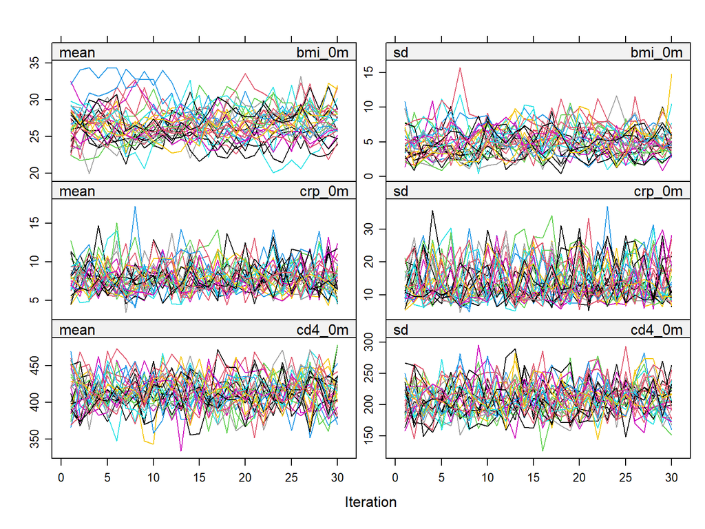

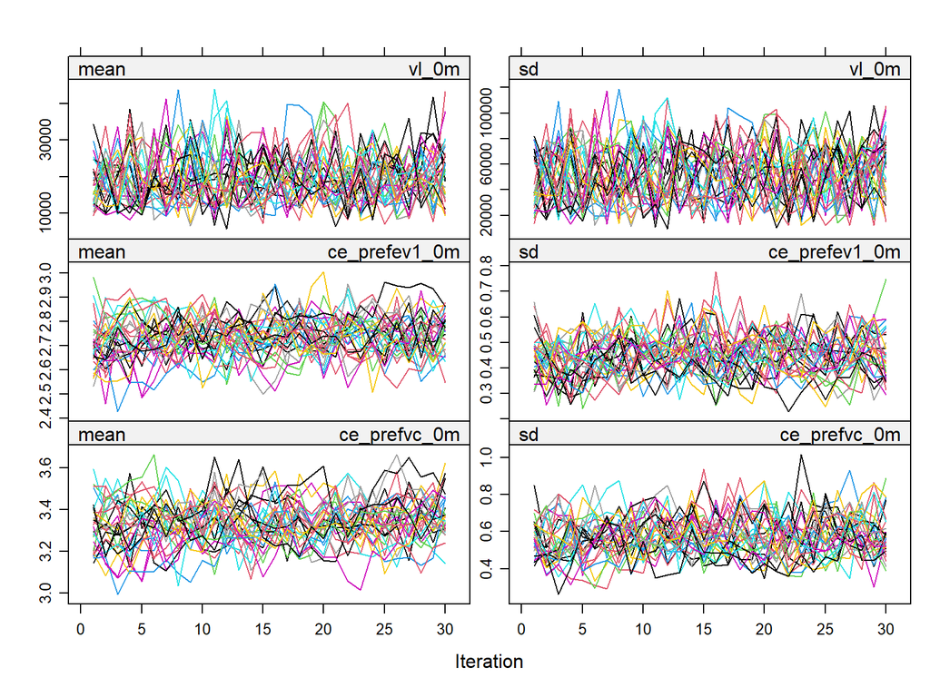

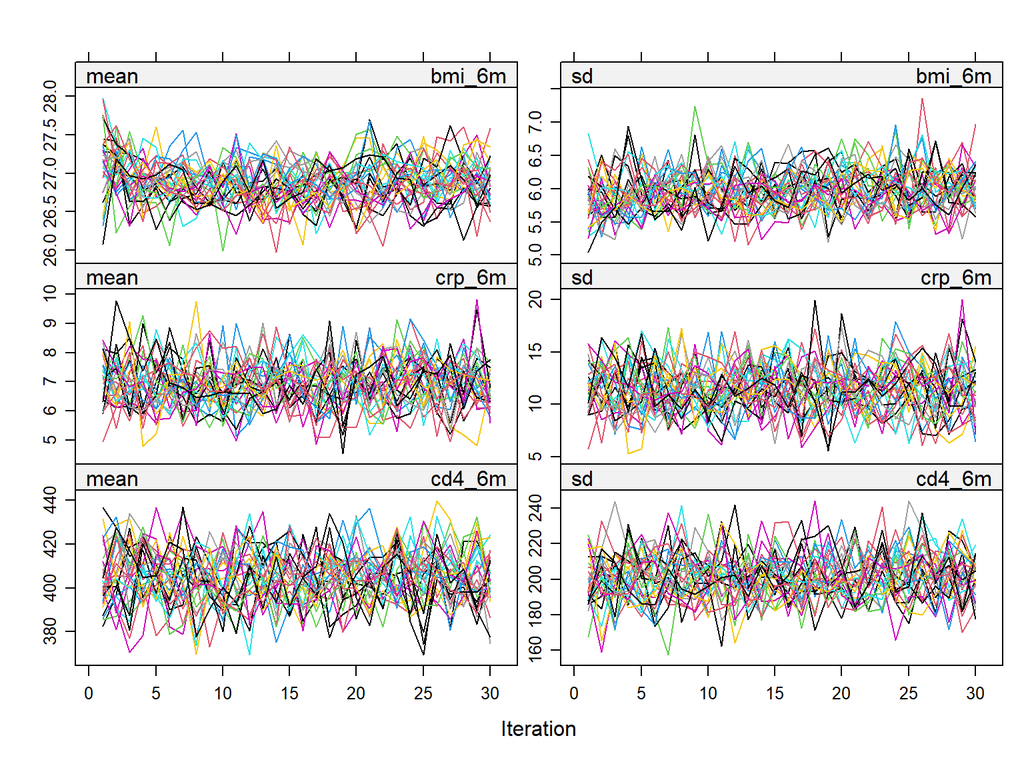

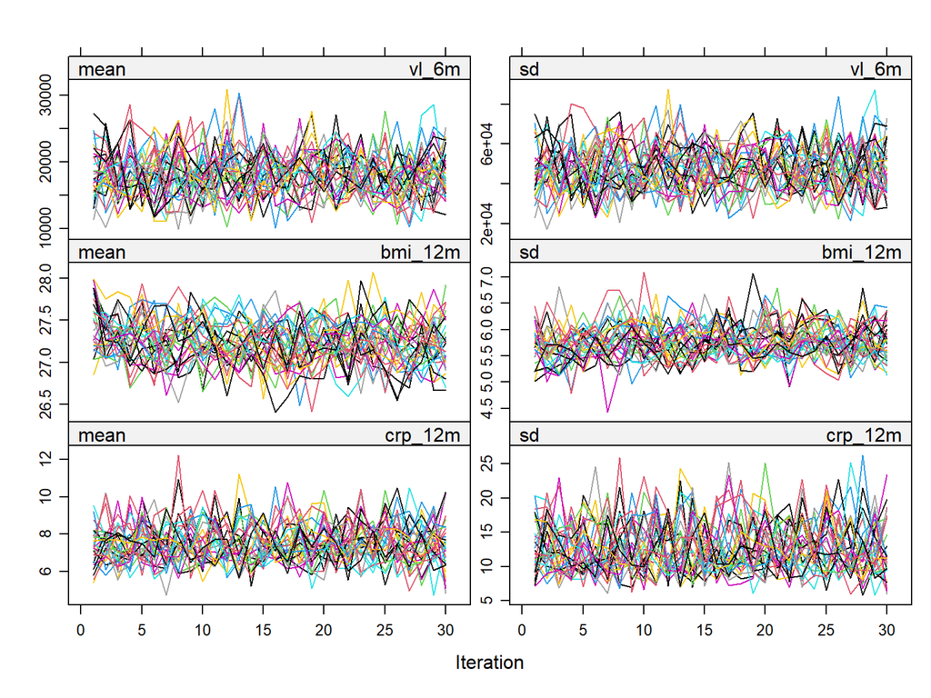

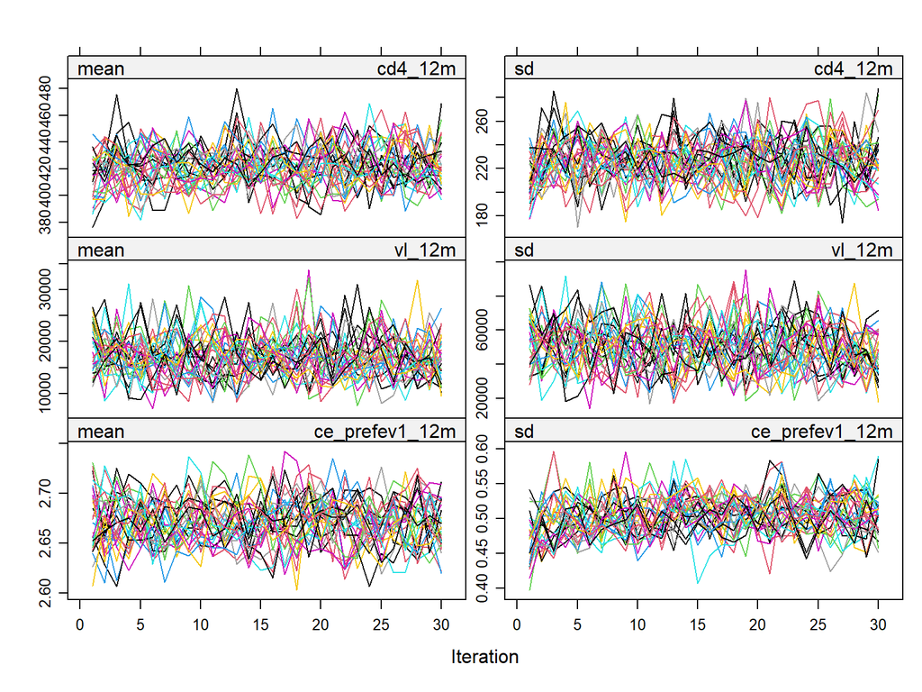

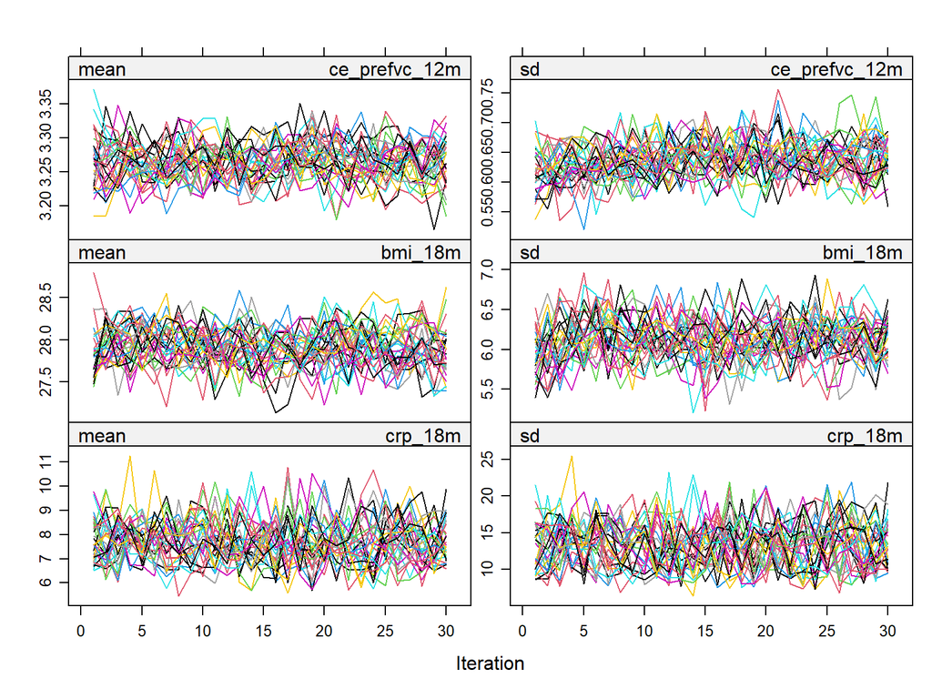

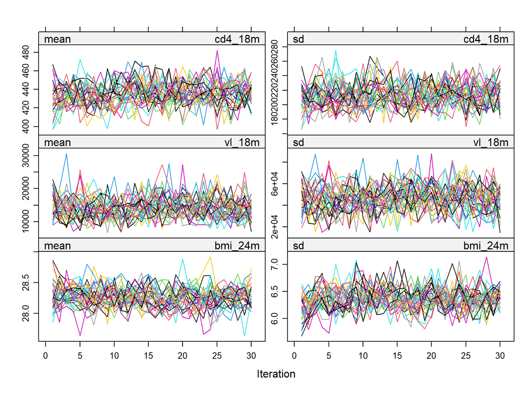

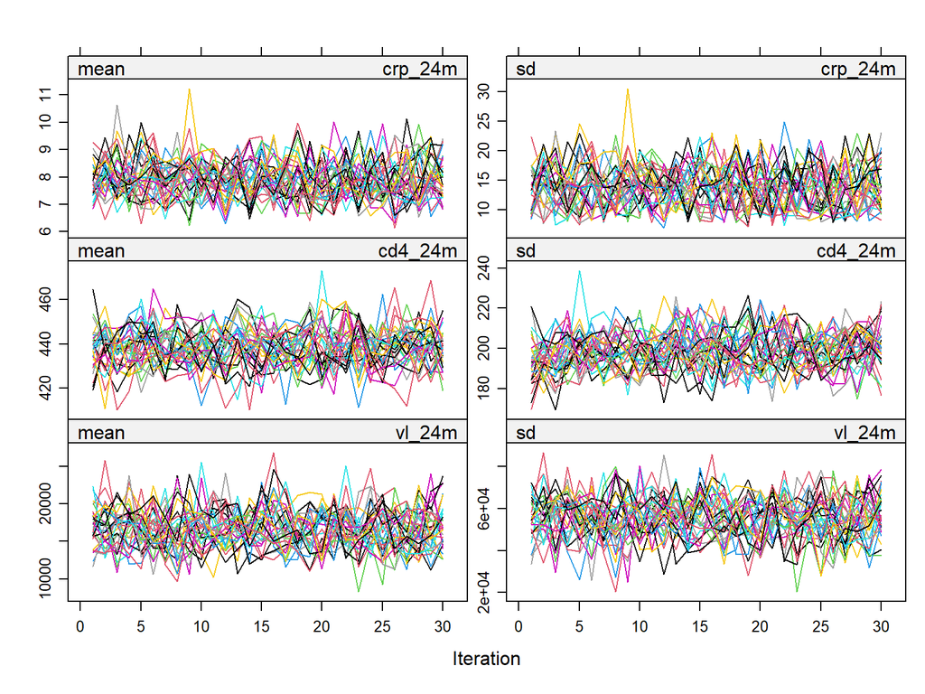

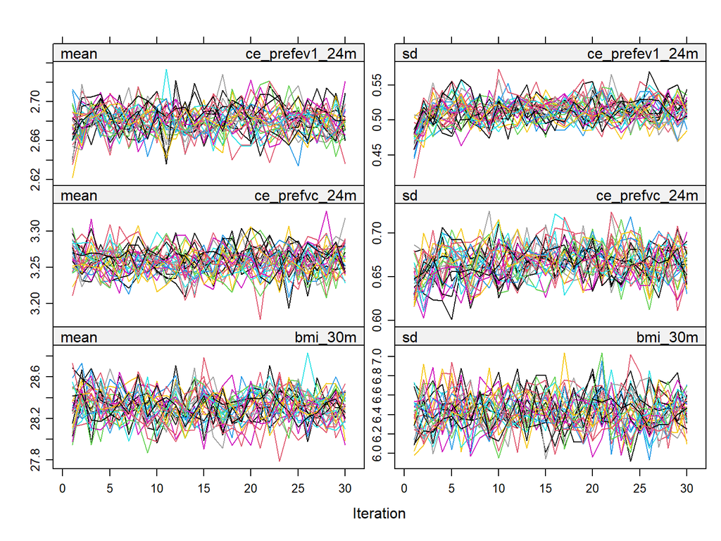

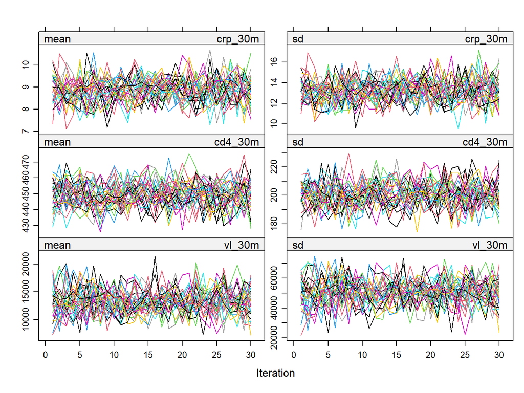

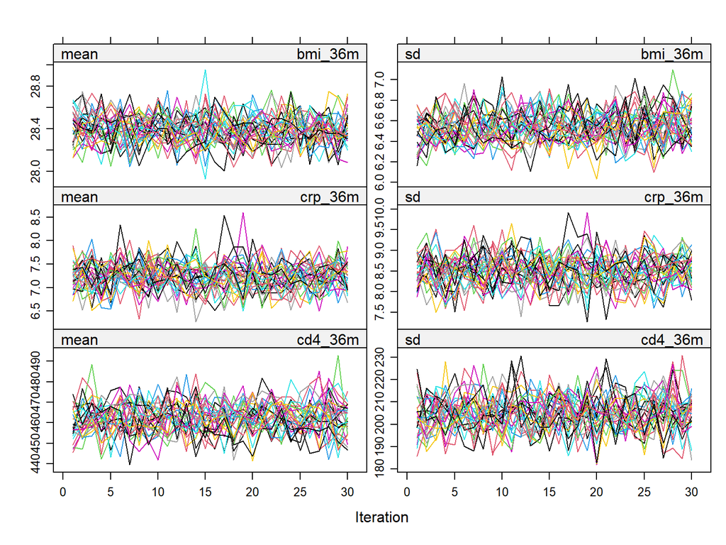

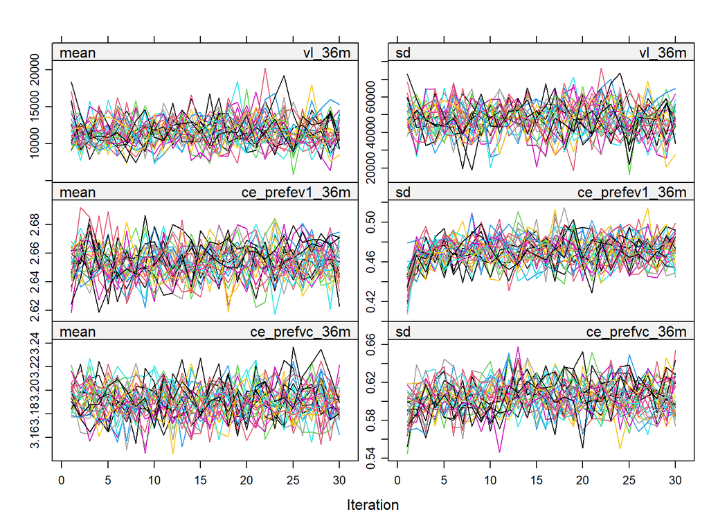

```r
plot(mice_obj)
```

Check the distribution of imputed against observed data. Baseline measurements:

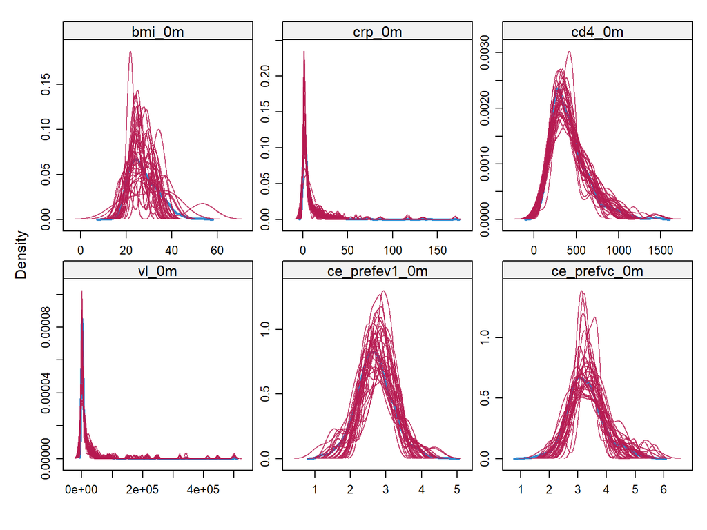

```r
densityplot(
  mice_obj,
  ~ bmi_0m + crp_0m + cd4_0m + vl_0m + ce_prefev1_0m + ce_prefvc_0m
)
```

At 6 months:

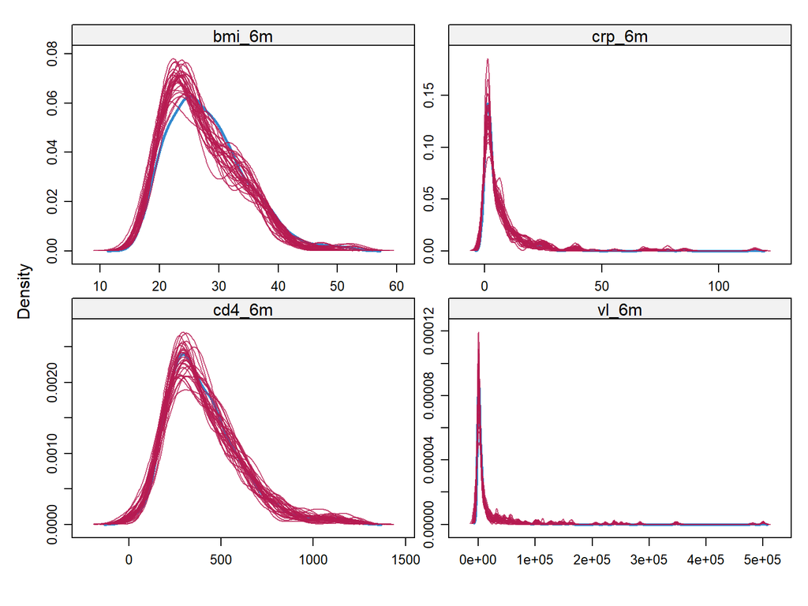

```r
densityplot(
  mice_obj,
  ~ bmi_6m + crp_6m + cd4_6m + vl_6m
)
```

At 12 months:

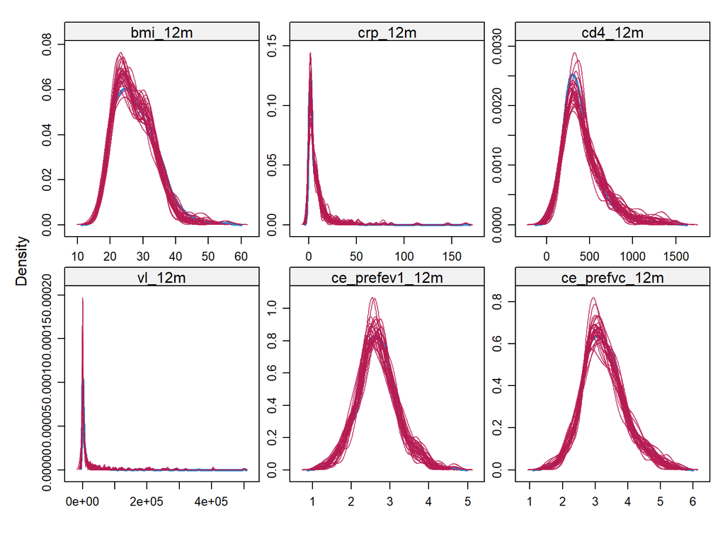

```r
densityplot(
  mice_obj,
  ~ bmi_12m + crp_12m + cd4_12m + vl_12m + ce_prefev1_12m + ce_prefvc_12m
)
```

At 18 months:

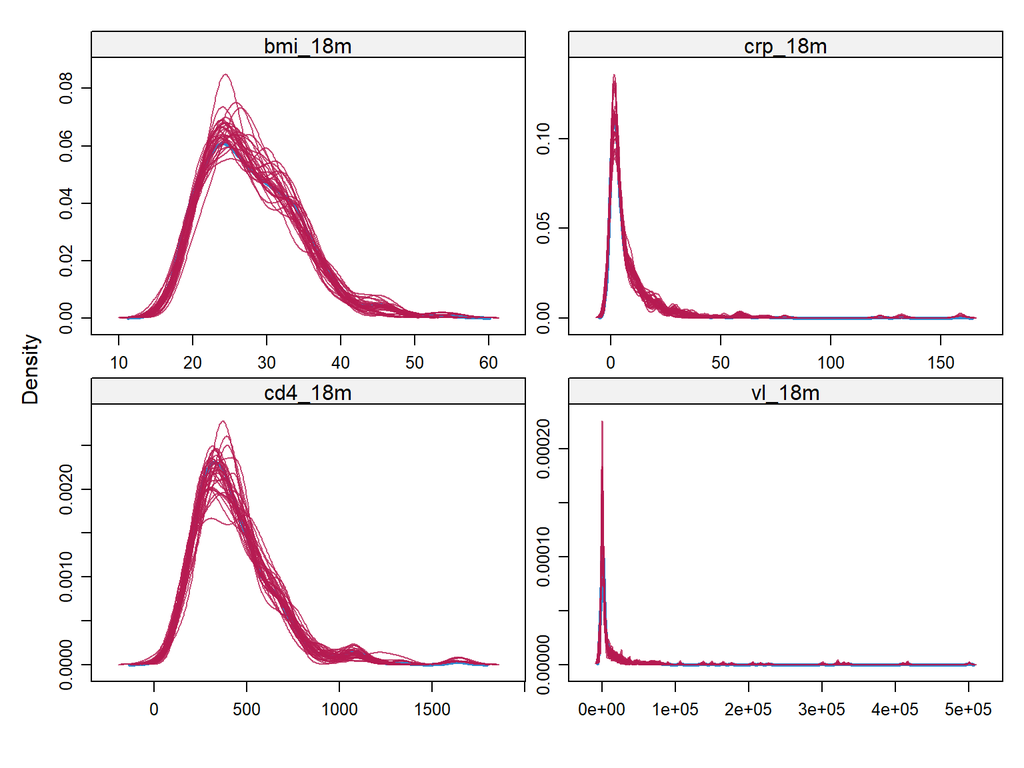

```r
densityplot(
  mice_obj,
  ~ bmi_18m + crp_18m + cd4_18m + vl_18m
)
```

At 24 months:

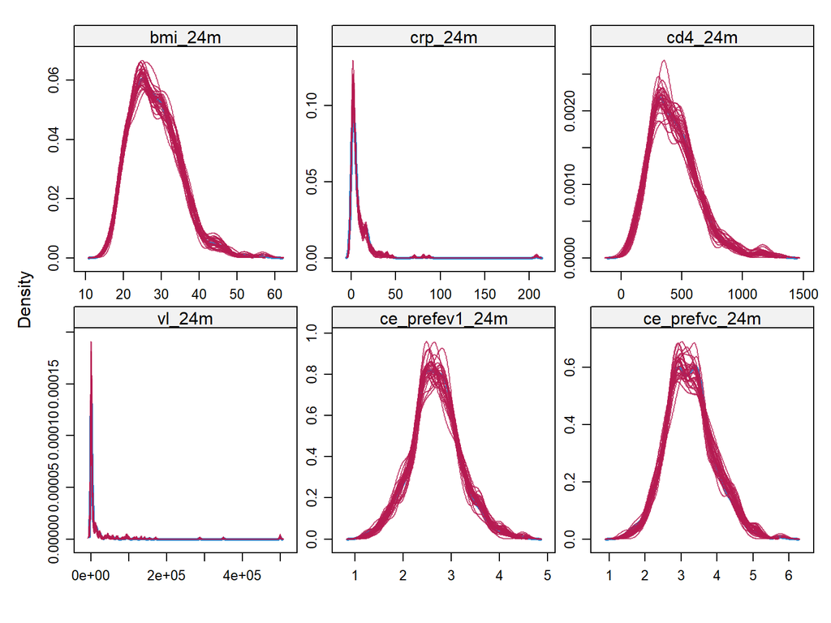

```r
densityplot(
  mice_obj,
  ~ bmi_24m + crp_24m + cd4_24m + vl_24m + ce_prefev1_24m + ce_prefvc_24m
)
```

At 30 months:

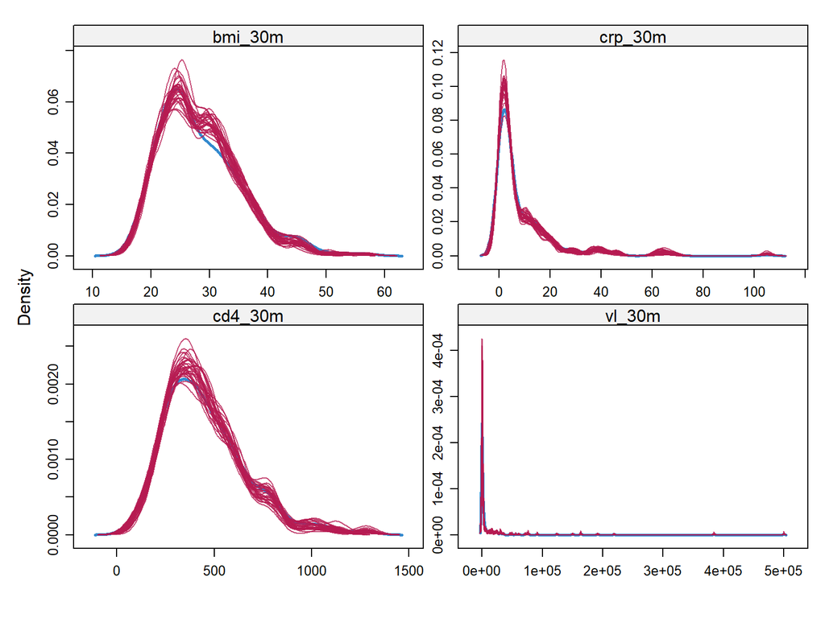

```r
densityplot(
  mice_obj,
  ~ bmi_30m + crp_30m + cd4_30m + vl_30m
)
```

At 36 months:

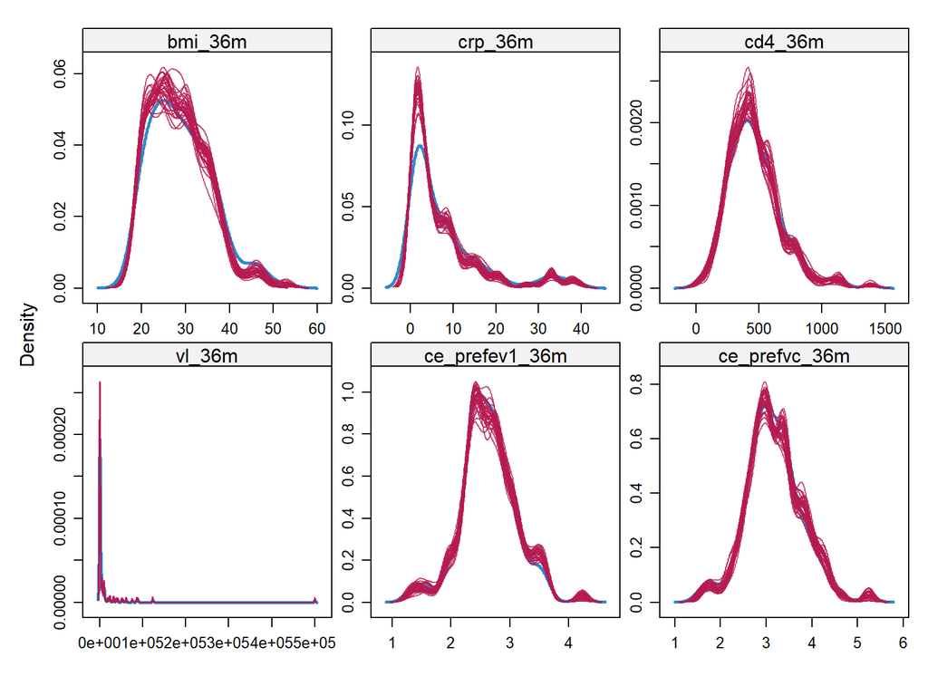

```r
densityplot(
  mice_obj,
  ~ bmi_36m + crp_36m + cd4_36m + vl_36m + ce_prefev1_36m + ce_prefvc_36m
)
```

The distributions of imputed data nicely resembled those of observed data.

Reshape the imputed datasets in the long format and store them into a `mids` object:

```r
imp_data <- complete(mice_obj, action = "all", include = TRUE) |>
  imap(
    \(x, y) {

      # Baseline dataset
      bs <- x |>
        dplyr::select(ptid:ce_prefvc_0m) |>
        mutate(
          # Indicator of whether VL is below the LOD
          vl_dl_0m = factor(
            if_else(vl_0m == 49, "below LD", "above LD"),
            levels = c("above LD", "below LD")
          ),
          # FEV1/FVC
          ce_prefev1_fvc_0m = ce_prefev1_0m/ce_prefvc_0m
        )

      # 6, 18, 30 months measurements dataset
      six_m <- x |>
        dplyr::select(
          ptid, bmi_6m:vl_6m, bmi_18m:vl_18m, bmi_30m:vl_30m
        ) |>
        pivot_longer(-c(ptid), names_to = "vars", values_to = "vals") |>
        separate(vars, c("pars", "visit"), sep = "_") |>
        pivot_wider(names_from = pars, values_from = vals) |>
        mutate(
          visit = as.integer(case_when(
            visit == "6m" ~ 12,
            visit == "18m" ~ 24,
            visit == "30m" ~ 36
          ))
        ) |>
        rename_with(~ str_c(.x, "_6m"), bmi:vl) |>
        # Indicator of whether VL is below the LOD
        mutate(
          vl_dl_6m = factor(
            if_else(vl_6m == 49, "below LD", "above LD"),
            levels = c("above LD", "below LD")
          )
        )

      # 12, 24, 36 months measurements dataset
      year_m <- x |>
        dplyr::select(
          ptid,
          bmi_12m:ce_prefvc_12m,
          bmi_24m:ce_prefvc_24m,
          bmi_36m:ce_prefvc_36m
        ) |>
        pivot_longer(-c(ptid), names_to = "vars", values_to = "vals") |>
        mutate(
          pars = case_when(
            str_detect(vars, "bmi") ~ "bmi",
            str_detect(vars, "crp") ~ "crp",
            str_detect(vars, "cd4") ~ "cd4",
            str_detect(vars, "vl") ~ "vl",
            str_detect(vars, "ce_prefev1") ~ "ce_prefev1",
            str_detect(vars, "ce_prefvc") ~ "ce_prefvc"
          ),
          visit = as.integer(case_when(
            str_detect(vars, "12m") ~ 12,
            str_detect(vars, "24m") ~ 24,
            str_detect(vars, "36m") ~ 36
          ))
        ) |>
        dplyr::select(-vars) |>
        pivot_wider(names_from = pars, values_from = vals) |>
        mutate(
          # Indicator of whether VL is below the LOD
          vl_dl = factor(
            if_else(vl == 49, "below LD", "above LD"),
            levels = c("above LD", "below LD")
          ),
          # FEV1/FVC
          ce_prefev1_fvc = ce_prefev1/ce_prefvc
        )

      # Join the datasets
      imp_long <- six_m |>
        left_join(year_m, by = c("ptid", "visit")) |>
        left_join(bs, by = "ptid") |>
        rowid_to_column(var = ".id") |>
        mutate(.imp = as.numeric(y), .before = 1L)

    }
  )

imp_data_mids <- as.mids(list_rbind(imp_data))
```

Save the imputed datasets:

```r
readr::write_rds(
  x = imp_data_mids,
  file = here::here("case_studies", "pi_hiv", "imp_datasets.rds")
)
```

# 4 Session Info

```r
print(si, locale = FALSE)
```

[output not shown]

# References

Buuren, S. van. 2018. *Flexible Imputation of Missing Data. Second Edition*. Boca Raton, FL: Chapman & Hall/CRC Press.

R. Little, D. Rubin. 2019. *Statistical Analysis with Missing Data, Third Edition*. John Wiley & Sons, Inc.

S. Van Buuren, C. G. M. Groothuis-Oudshoorn, J. P. L. Brand, and D. B. Rubin. 2006. “Fully Conditional Specification in Multivariate Imputation.” *Journal of Statistical Computation and Simulation* 76 (12): 1049–64. https://doi.org/10.1080/10629360600810434.